# F1 Prediction

# FORMULA 1 CHAMPIONSHIP EDA AND WINNER PREDICTION

For the project of Data Analaysis technique and tools we decided to select a dataset from Kaggle containing the results of Formula 1 Races from 1950 to today. First we have performed data merging between all the different dataframes into one final dataframe (`df`) that contains all the numerical and categorical features that we found relevant and useful for the initial data analaysis and the subsequent application of machine learning methods. In the last part we tried to predict the winner of a Formula 1 race contained in our dataset using both regression and classification techniques. This was our major goal and the criterion that guided our analysis throughout the project.

## Loading libraries

```r
library(ggplot2)
library(dplyr)
library(rpart)
library(corrplot)
library(treemap)
library(treemapify)
library(tree)
library(randomForest)
library(caret)
library(e1071)
library(rpart.plot)
library(car)
```

## Data loading

```r
df = read.csv("~/Library/Mobile Documents/com~apple~CloudDocs/UNICATT/Data analysis techniques and tools/F1_prediction/datasets/df.csv")
str(df)
```

```
## 'data.frame':    23693 obs. of  25 variables:
##  $ raceId          : int  1 1 1 1 1 1 1 1 1 1 ...
##  $ driverId        : int  10 15 16 17 18 2 20 21 22 3 ...
##  $ constructorId   : int  7 7 10 9 23 2 9 10 23 3 ...
##  $ circuitId       : int  1 1 1 1 1 1 1 1 1 1 ...
##  $ resultId        : int  7557 7556 7562 7565 7554 7563 7566 7564 7555 7559 ...
##  $ number          : int  10 9 20 14 22 6 15 21 23 16 ...
##  $ grid            : int  19 20 16 8 1 9 3 15 2 5 ...
##  $ positionOrder   : int  4 3 9 12 1 10 13 11 2 6 ...
##  $ points          : num  5 6 0 0 10 0 0 0 8 3 ...
##  $ laps            : int  58 58 58 57 58 58 56 58 58 58 ...
##  $ fastestLapSpeed : num  216 215 215 216 217 ...
##  $ status          : chr  "Finished" "Finished" "Finished" "+1 Lap" ...
##  $ dob             : chr  "1982-03-18" "1974-07-13" "1983-01-11" "1976-08-27" ...
##  $ driv_nationality: chr  "German" "Italian" "German" "Australian" ...
##  $ fullname        : chr  "Timo Glock" "Jarno Trulli" "Adrian Sutil" "Mark Webber" ...
##  $ round           : int  1 1 1 1 1 1 1 1 1 1 ...
##  $ date            : chr  "2009-03-29" "2009-03-29" "2009-03-29" "2009-03-29" ...
##  $ const_name      : chr  "Toyota" "Toyota" "Force India" "Red Bull" ...
##  $ name            : chr  "Albert Park Grand Prix Circuit" "Albert Park Grand Prix Circuit" "Albert Park Grand Prix Circuit" "Albert Park Grand Prix Circuit" ...
##  $ const_points    : num  11 11 0 0 18 0 0 0 18 3 ...
##  $ const_wins      : int  0 0 0 0 1 0 0 0 1 0 ...
##  $ driver_age      : int  27 35 26 33 29 32 22 36 37 24 ...
##  $ fastestLap_ms   : num  88416 88916 88943 88508 88020 ...
##  $ winner          : int  0 0 0 0 1 0 0 0 0 0 ...
##  $ wins            : int  1 1 1 1 2 1 1 1 1 1 ...
```

```r
head(df)
```

```
##   raceId driverId constructorId circuitId resultId number grid positionOrder
## 1      1       10             7         1     7557     10   19             4
## 2      1       15             7         1     7556      9   20             3
## 3      1       16            10         1     7562     20   16             9
## 4      1       17             9         1     7565     14    8            12
## 5      1       18            23         1     7554     22    1             1
## 6      1        2             2         1     7563      6    9            10
##   points laps fastestLapSpeed   status        dob driv_nationality
## 1      5   58         215.920 Finished 1982-03-18           German
## 2      6   58         214.706 Finished 1974-07-13          Italian
## 3      0   58         214.640 Finished 1983-01-11           German
## 4      0   57         215.695   +1 Lap 1976-08-27       Australian
## 5     10   58         216.891 Finished 1980-01-19          British
## 6      0   58         216.245 Finished 1977-05-10           German
##        fullname round       date  const_name                           name
## 1    Timo Glock     1 2009-03-29      Toyota Albert Park Grand Prix Circuit
## 2  Jarno Trulli     1 2009-03-29      Toyota Albert Park Grand Prix Circuit
## 3  Adrian Sutil     1 2009-03-29 Force India Albert Park Grand Prix Circuit
## 4   Mark Webber     1 2009-03-29    Red Bull Albert Park Grand Prix Circuit
## 5 Jenson Button     1 2009-03-29       Brawn Albert Park Grand Prix Circuit
## 6 Nick Heidfeld     1 2009-03-29  BMW Sauber Albert Park Grand Prix Circuit
##   const_points const_wins driver_age fastestLap_ms winner wins
## 1           11          0         27         88416      0    1
## 2           11          0         35         88916      0    1
## 3            0          0         26         88943      0    1
## 4            0          0         33         88508      0    1
## 5           18          1         29         88020      1    2
## 6            0          0         32         88283      0    1
```

Our starting dataframe `df` is composed by 25 columns of features that define for each row a Driver performance in a specific Race of a specific year. So for each row:

- 5 columns describe the unique observation: `raceId`, `driverId`, `constructorId`, `circuitId`, `resultId`. They were useful in the initial part of the data processing to merge multiple features from other datasets into this one main dataframe that include all the features that we later use for data analysis and prediction.
- 2 columns define the perfomance of the driver in the specific race, mainly `positionOrder` and the binary `winner`. These are the target variables of the regression and classification methods.
- 11 columns are numerical features used:
  - `number`, number of each driver’s car
  - `grid`, starting position for the driver
  - `points`, number of points earned in the race
  - `laps`, number of laps in the race
  - `fastestLapSpeed`
  - `round`, number of the Race in the season
  - `const_points`, number of points earned by the team before this race
  - `const_wins`, number of wins of the team before the race
  - `driver_age`, age of each driver
  - `fastestLap_ms`, fastest lap in the qualification race
  - `wins`, number of wins before the race for the driver
- 5 columns that describe categorical features:
  - `status`, what happened in the race for the driver
  - `driv_nationality`
  - `fullname`, name of the driver
  - `const_name`, name of the team
  - `name`, name of the circuit in which the race takes place
- 2 columns for dates: `dob` is birth date for each driver, `date` is the date of the Race.

# EDA and plots.

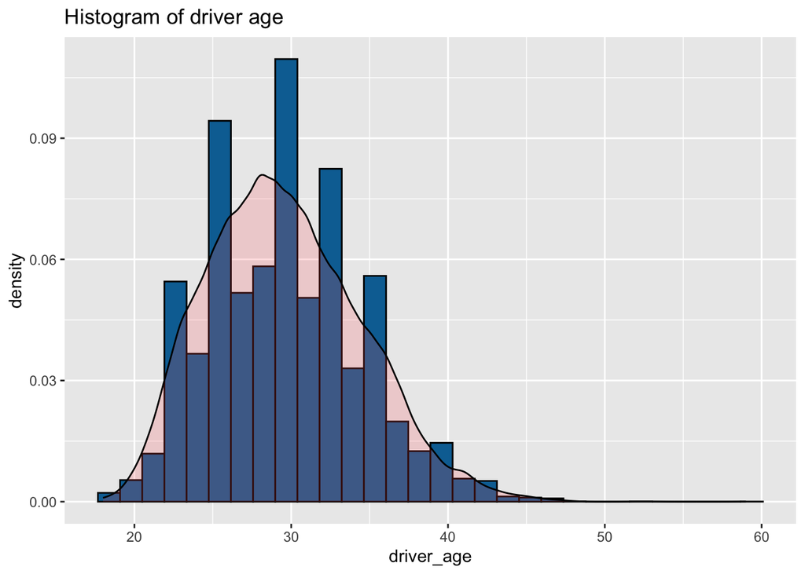

```r
ggplot(df, aes(x=driver_age)) +
 geom_histogram(aes(y=after_stat(density)), colour="black", fill= '#076fa2')+
 geom_density(alpha=.2, fill="#FF6666") +
 labs(title = 'Histogram of driver age')
```

The frequency of the drivers’ age from 1950 to 2022 can be traced to a normal distribution, with a peak around 30 years old. Since the column driver_age from the data frame collects also the various age during which the drivers have raced, we can interpret this histogram also like an indicator of the retirement age of a pilot: we have a peak around 30 years old and then as the age increase its frequency decrease, so we have less and less pilot with an higher age.

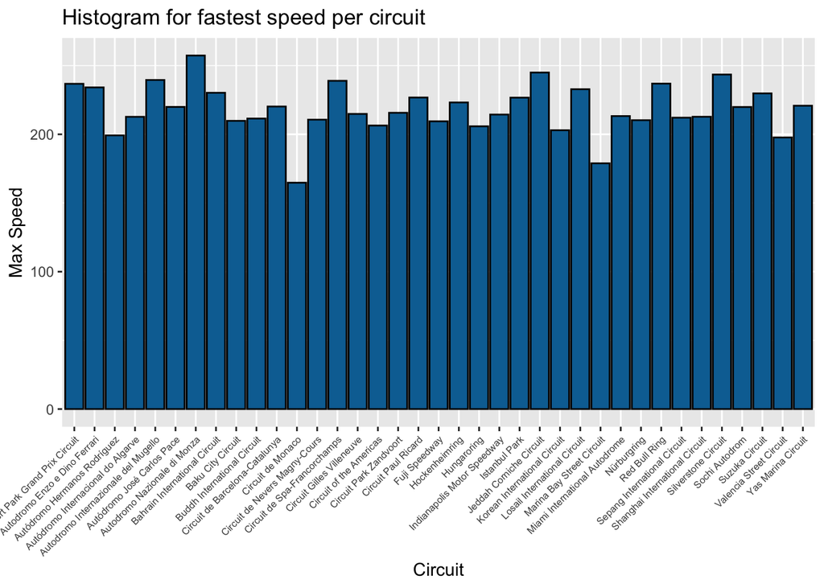

```r
df_speed <- read.csv('~/Library/Mobile Documents/com~apple~CloudDocs/UNICATT/Data analysis techniques and tools/F1_prediction/datasets/df_speed.csv')
ggplot(df_speed, aes(x=Circuit, y=Max_Speed)) +
 geom_bar(colour="black", fill= '#076fa2', stat = 'identity')+
 labs(title = 'Histogram for fastest speed per circuit', x = 'Circuit', y = 'Max Speed') +
 theme(axis.text.x = element_text(angle = 45, vjust = 1, hjust = 1, size = 6))
```

This bar plot shows the fastest lap speed for every circuit (where it has been registered, since sometimes there isn’t a max speed for a circuits, especially the oldest). From here we can see where a driver can dare the most with the accelerator.

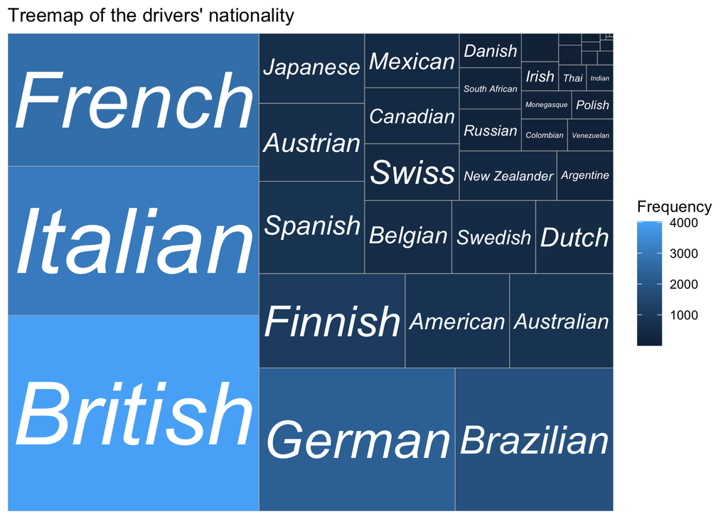

```r
nationality = data.frame(table(df$driv_nationality))
nationality$Var1 = as.character(nationality$Var1)
ggplot(nationality, aes(area = Freq, fill = Freq, label = Var1)) +
  geom_treemap() +
  geom_treemap_text(fontface = "italic", colour = "white", place = "centre",
                    grow = TRUE) +
  labs(title = "Treemap of the drivers' nationality", fill = "Frequency")
```

This histogram shows the frequency of every circuit over time.

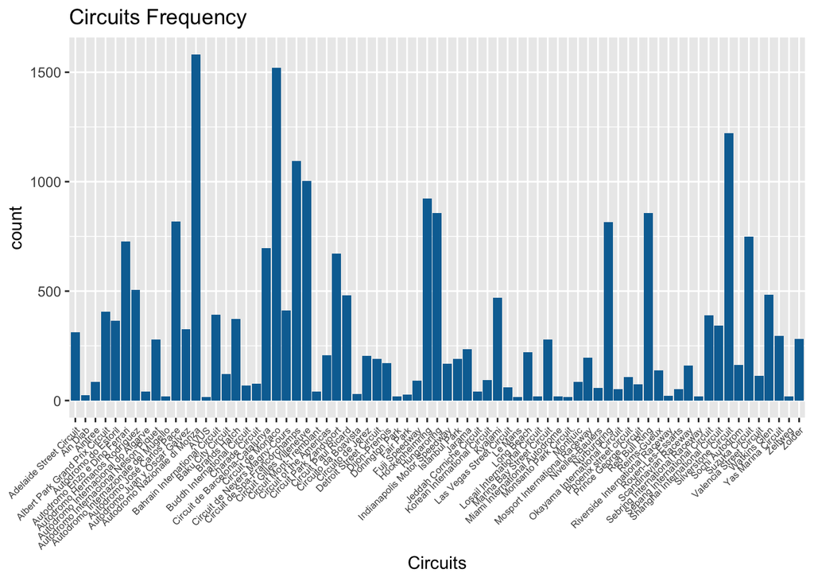

```r
ggplot(df, aes(name)) +
  labs(x = 'Circuits') +
  ggtitle('Circuits Frequency') +
  geom_bar(fill="#076fa2", position = position_dodge(0.7)) +
  theme(axis.text.x = element_text(angle = 45, vjust = 1, hjust = 1, size = 6))
```

Most dangerous circuits

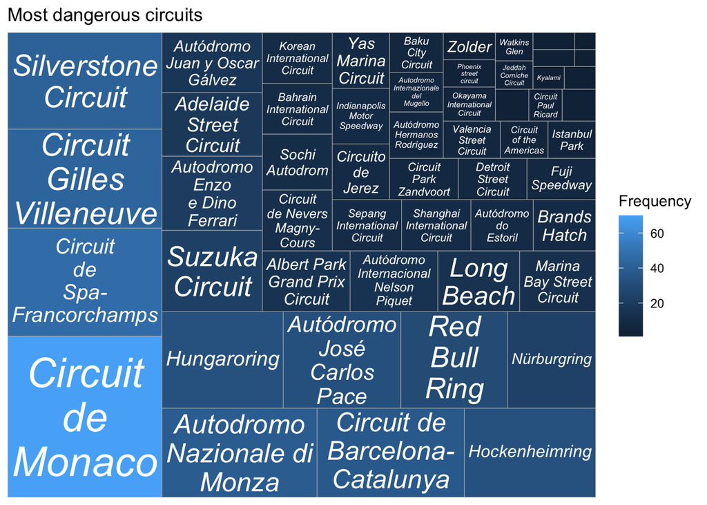

```r
n_collision <- table(df[df$status == 'Collision', 'name'])
n_collision <- as.data.frame(n_collision)

ggplot(n_collision, aes(area = Freq, fill = Freq, label = Var1)) +
  geom_treemap() +
  geom_treemap_text(fontface = "italic", colour = "white", place = "centre", reflow = TRUE, grow = TRUE) +
  labs(title = "Most dangerous circuits", fill = "Frequency")
```

Accident ratio per circuit.

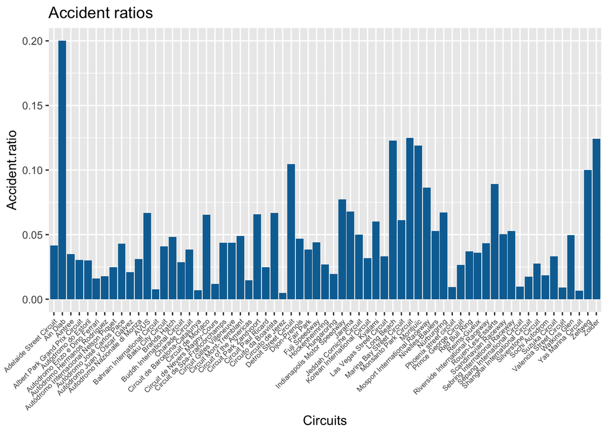

```r
n_accident = read.csv("~/Library/Mobile Documents/com~apple~CloudDocs/UNICATT/Data analysis techniques and tools/F1_prediction/datasets/n_accident.csv")
ggplot(n_accident, aes(x = as.character(Accident.Names), y = Accident.ratio)) +
  labs(x = 'Circuits') +
  ggtitle('Accident ratios') +
  geom_bar(fill="#076fa2", position = position_dodge(0.7), stat = 'identity') +
  theme(axis.text.x = element_text(angle = 45, vjust = 1, hjust = 1, size = 6))
```

Winning driver age overtime

```r
df_points = read.csv("~/Library/Mobile Documents/com~apple~CloudDocs/UNICATT/Data analysis techniques and tools/F1_prediction/datasets/df_points.csv")
```

```r
#define a function to extract age of the championship's winner for every year
winner_Age = function(){
  df_year_winner = matrix(nrow = 1, ncol=5)
  years = seq(1958, 2022, 1)
  for (y in years){
    df_year = df_points[df_points$year == y, c(2,4,9,10)]
    id_winner = df_year[which.max(df_year$points), ]
    df_year_winner <- rbind(df_year_winner, c(y, id_winner$driverId,
                    id_winner$points, id_winner$fullname, id_winner$driver_age))
  }
  df_year_winner = data.frame(df_year_winner)
  df_year_winner = df_year_winner[-1,]
  return(df_year_winner)
}
df_year_winner = winner_Age()
names(df_year_winner) = c('year', 'driverId', 'final_points', 'fullname', 'age')
df_year_winner$age = as.numeric(df_year_winner$age)
head(df_year_winner)
```

```
##   year driverId final_points      fullname age
## 2 1958      578           42 Mike Hawthorn  29
## 3 1959      356           31  Jack Brabham  33
## 4 1960      356           43  Jack Brabham  34
## 5 1961      403           34     Phil Hill  34
## 6 1962      289           42   Graham Hill  33
## 7 1963      373           54     Jim Clark  27
```

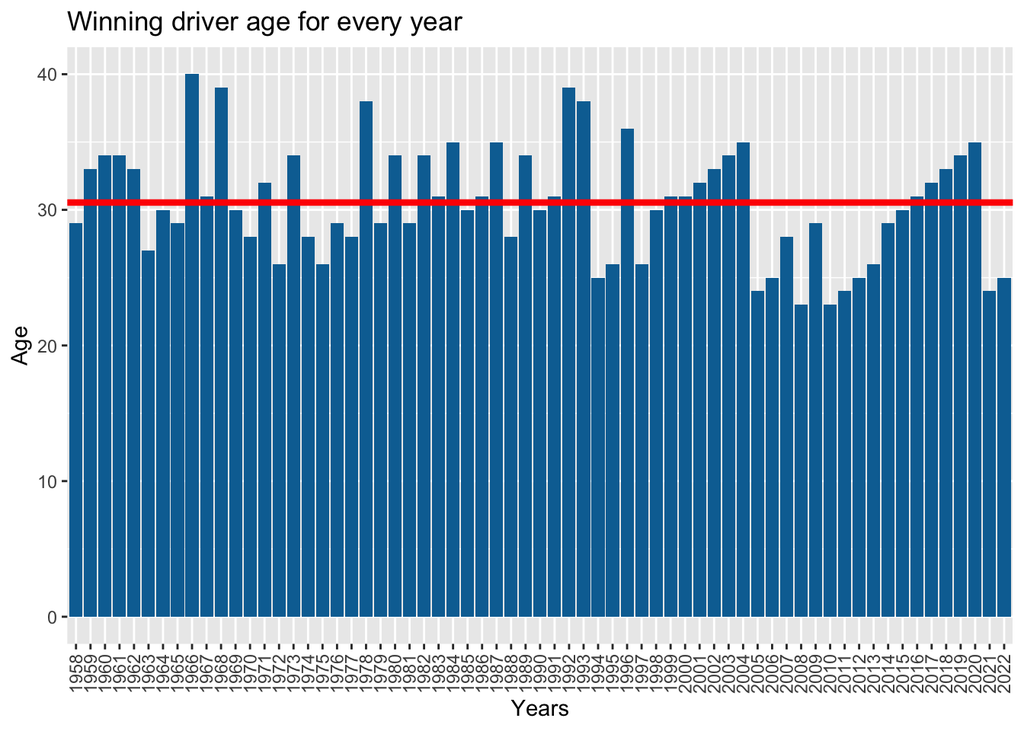

```r
#plot for winner's age over time
ggplot(df_year_winner, aes(x = year, y = age)) +
  labs(x = 'Years', y = 'Age') +
  ggtitle('Winning driver age for every year') +
  geom_bar(stat = "identity") +
  geom_col(fill = "#076fa2") +
  theme(axis.text.x = element_text(angle = 90, vjust=0.5, hjust = 1)) +
  geom_abline(slope = 0, intercept = mean(df_year_winner$age),
              color = 'red', linewidth = 1.5)
```

How important is the pole position in each circuit to win the race? Each column is the ratio between how many times a driver have won a race after he has qualified first.

```r
pole_ratio = read.csv("~/Library/Mobile Documents/com~apple~CloudDocs/UNICATT/Data analysis techniques and tools/F1_prediction/datasets/pole_ratio.csv")
```

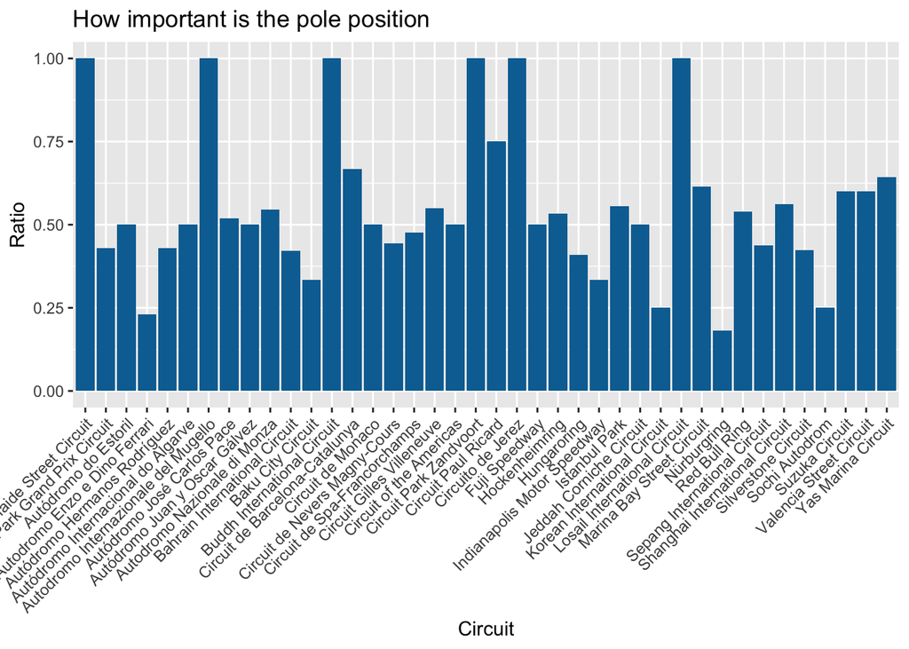

```r
ggplot(pole_ratio, aes(x = X1, y = X2)) +
  labs(x = 'Circuit', y = 'Ratio') +
  ggtitle('How important is the pole position') +
  geom_bar(stat = "identity") +
  geom_col(fill = "#076fa2") +
  theme(axis.text.x = element_text(angle = 45, hjust = 1))
```

Correlation MATRIX to look for relationships between numerical features.

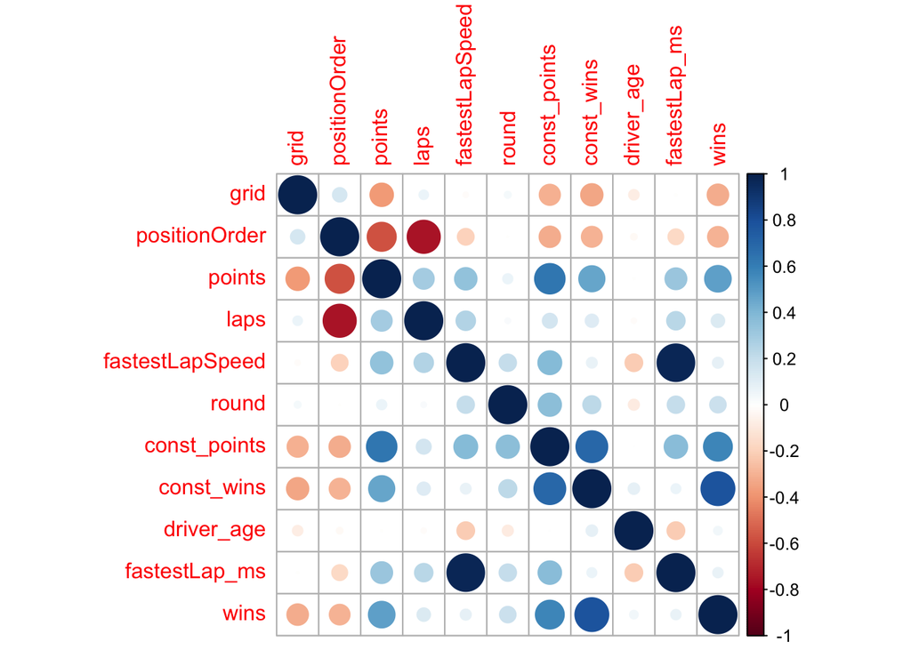

```r
corr_matrix = cor(df[c(7,8,9,10,11,16,20,21,22,23,25)])
corrplot(corr_matrix)
```

# DEFINING AND TRAINING ML MODELS FOR PREDICTION.

```r
df$winner = as.factor(df$winner) #converting the column to a factor.
```

### Partition the data for train and validation.

For partitioning the data, we decided to use a different approach. Instead of just randomly select rows from the original dataset (we recall that each row is a driver’s performance in a specific race) we decided to create a block of rows for each race (with each block containing multiple observation, i.e. all the drivers that attained the race) and randomly select 80% blocks for the training sample and the rest for the testing sample.

We decided to partition the data in this way in order to maintain the integrity of observations for each race. Otherwise, we could have situations in which in the testing sets there is just one driver for a Race, and so his performance would be assessed in the lack of opponents.

```r
races_list = unique(df$raceId)
races_train_idx = sample(length(races_list), length(races_list)*0.8)

races_train_list = races_list[races_train_idx]
races_test_list = races_list[-races_train_idx]

#creating train & test dataframes
df.train = df[df$raceId %in% races_train_list, ]
df.test = df[df$raceId %in% races_test_list, ]
```

Fixing `df.train` and `df.test` for categorical features by converting those columns in factors.

```r
df.train$status = as.factor(df.train$status)
df.train$driv_nationality = as.factor(df.train$driv_nationality)
df.train$fullname = as.factor(df.train$fullname)
df.train$const_name = as.factor(df.train$const_name)
df.train$name = as.factor(df.train$name)
str(df.train)
```

```
## 'data.frame':    19047 obs. of  25 variables:
##  $ raceId          : int  1 1 1 1 1 1 1 1 1 1 ...
##  $ driverId        : int  10 15 16 17 18 2 20 21 22 3 ...
##  $ constructorId   : int  7 7 10 9 23 2 9 10 23 3 ...
##  $ circuitId       : int  1 1 1 1 1 1 1 1 1 1 ...
##  $ resultId        : int  7557 7556 7562 7565 7554 7563 7566 7564 7555 7559 ...
##  $ number          : int  10 9 20 14 22 6 15 21 23 16 ...
##  $ grid            : int  19 20 16 8 1 9 3 15 2 5 ...
##  $ positionOrder   : int  4 3 9 12 1 10 13 11 2 6 ...
##  $ points          : num  5 6 0 0 10 0 0 0 8 3 ...
##  $ laps            : int  58 58 58 57 58 58 56 58 58 58 ...
##  $ fastestLapSpeed : num  216 215 215 216 217 ...
##  $ status          : Factor w/ 126 levels "+1 Lap","+10 Laps",..: 61 61 61 1 61 61 35 61 61 61 ...
##  $ dob             : chr  "1982-03-18" "1974-07-13" "1983-01-11" "1976-08-27" ...
##  $ driv_nationality: Factor w/ 41 levels "American","American-Italian",..: 19 24 19 5 9 19 19 24 8 19 ...
##  $ fullname        : Factor w/ 583 levels "Adrián Campos",..: 544 265 2 362 278 406 515 193 508 408 ...
##  $ round           : int  1 1 1 1 1 1 1 1 1 1 ...
##  $ date            : chr  "2009-03-29" "2009-03-29" "2009-03-29" "2009-03-29" ...
##  $ const_name      : Factor w/ 155 levels "AGS","Alfa Romeo",..: 148 148 56 124 22 14 124 56 22 153 ...
##  $ name            : Factor w/ 72 levels "Adelaide Street Circuit",..: 4 4 4 4 4 4 4 4 4 4 ...
##  $ const_points    : num  11 11 0 0 18 0 0 0 18 3 ...
##  $ const_wins      : int  0 0 0 0 1 0 0 0 1 0 ...
##  $ driver_age      : int  27 35 26 33 29 32 22 36 37 24 ...
##  $ fastestLap_ms   : num  88416 88916 88943 88508 88020 ...
##  $ winner          : Factor w/ 2 levels "0","1": 1 1 1 1 2 1 1 1 1 1 ...
##  $ wins            : int  1 1 1 1 2 1 1 1 1 1 ...
```

```r
df.test$status = as.factor(df.test$status)
df.test$driv_nationality = as.factor(df.test$driv_nationality)
df.test$fullname = as.factor(df.test$fullname)
df.test$const_name = as.factor(df.test$const_name)
df.test$name = as.factor(df.test$name)
str(df.test)
```

```
## 'data.frame':    4646 obs. of  25 variables:
##  $ raceId          : int  1004 1004 1004 1004 1004 1004 1004 1004 1004 1004 ...
##  $ driverId        : int  1 154 20 4 8 807 815 817 822 825 ...
##  $ constructorId   : int  131 210 6 1 6 4 10 9 131 210 ...
##  $ circuitId       : int  71 71 71 71 71 71 71 71 71 71 ...
##  $ resultId        : int  24083 24093 24085 24096 24086 24094 24092 24088 24084 24090 ...
##  $ number          : int  44 8 5 14 7 27 11 3 77 20 ...
##  $ grid            : int  2 9 3 16 4 12 8 18 1 5 ...
##  $ positionOrder   : int  1 11 3 14 4 12 10 6 2 8 ...
##  $ points          : num  25 0 15 0 12 0 1 8 18 4 ...
##  $ laps            : int  53 52 53 52 53 52 52 53 53 52 ...
##  $ fastestLapSpeed : num  219 214 219 211 218 ...
##  $ status          : Factor w/ 89 levels "+1 Lap","+10 Laps",..: 41 1 41 1 41 1 1 41 41 1 ...
##  $ dob             : chr  "1985-01-07" "1986-04-17" "1987-07-03" "1981-07-29" ...
##  $ driv_nationality: Factor w/ 38 levels "American","American-Italian",..: 8 16 17 34 15 17 26 4 15 13 ...
##  $ fullname        : Factor w/ 424 levels "Adrián Campos",..: 240 360 371 114 232 293 375 75 409 231 ...
##  $ round           : int  16 16 16 16 16 16 16 16 16 16 ...
##  $ date            : chr  "2018-09-30" "2018-09-30" "2018-09-30" "2018-09-30" ...
##  $ const_name      : Factor w/ 128 levels "AGS","Alfa Romeo",..: 85 49 42 81 42 100 46 99 85 49 ...
##  $ name            : Factor w/ 55 levels "Adelaide Street Circuit",..: 51 51 51 51 51 51 51 51 51 51 ...
##  $ const_points    : num  495 80 442 58 442 91 35 292 495 80 ...
##  $ const_wins      : int  8 0 5 0 5 0 0 3 8 0 ...
##  $ driver_age      : int  33 32 31 37 39 31 28 29 29 26 ...
##  $ fastestLap_ms   : num  95916 98244 95990 99590 96611 ...
##  $ winner          : Factor w/ 2 levels "0","1": 2 1 1 1 1 1 1 1 1 1 ...
##  $ wins            : int  9 1 6 1 1 1 1 3 1 1 ...
```

Fixing FACTOR LEVELS in the testing dataframe.

When partitioning the data, categories for nominal features are shuffled between `df.train` and `df.test`. This lead to a situation in which categories in `df.test` could not be present in `df.train` and so classification models trained on `df.test` would not consider other categories that are only present in `df.test`.

With the following lines of code we overcome this problem by setting factor levels of all categorical columns of `df.test` to be exactly the same as `df.train`. Otherwise, we would encounter problems in the classifications method when predicting the new data from `df.test` using the model trained on `df.train`.

```r
levels(df.test$status) <- levels(df.train$status)
levels(df.test$driv_nationality) <- levels(df.train$driv_nationality)
levels(df.test$fullname) <- levels(df.train$fullname)
levels(df.test$const_name) <- levels(df.train$const_name)
levels(df.test$name) <- levels(df.train$name)
```

### SCORING FUNCTIONS

The two scoring functions we created, simply calculate the accuracy for the prediction of the winner of each race.

For the regressions, the scoring functions sort the prediction of `positionOrder` for each race (by using `raceId`) and take the smallest value for the prediction (since in the `positionsOrder` the winner has position 1, hence the smallest position). If the same driver (a row of df.test) has the real value of `positionOrder` equal to 1, then the prediction is correct and the score is increased by 1. After scrolling through all races that are contained in df.test, the `accuracy_score` is defined as the ratio between score and the number of races.

For the classification, the scoring function works similarly but there is a difference. We are using the classifications models to predict `winner` defined in {0,1} but the models in action are going to assign 1 to multiple drivers in the same race (but we can have just one winner in a race). So instead we look for the greatest probability among the driver of a race to have the winner feature equal to 1. The driver with the greatest probability of having the `winner` feature equal to 1 would be the driver with the greatest probability of winning the race and hence he is the winner our function pick. The definition of score works in the same way as in the scoring function for regressions.

Defining scoring function for Regression.

```r
score_regression <- function(test, prediction){

  df.score.regres = data.frame(test, prediction)
  colnames(df.score.regres)[c(26)] = c('prediction')

  racelist = unique(df.score.regres$raceId)

  score = 0
  for (i in 1:length(racelist)){
    race = df.score.regres[df.score.regres$raceId %in% racelist[i], ]
    pred_winner_idx = which.min(race$prediction)
    if (race$positionOrder[pred_winner_idx] == 1){
      score = score + 1
    }
  }

  score_ratio = score/length(racelist)
  return(score_ratio)
}
```

Defining scoring function for Classification.

```r
score_classification <- function(test, prediction){

  df.score.class = data.frame(test, prediction)
  colnames(df.score.class)[c(26,27)] = c('pred_0', 'pred_1')

  racelist = unique(df.score.class$raceId)

  score = 0
  for (i in 1:length(racelist)){
    race = df.score.class[df.score.class$raceId %in% racelist[i], ]
    pred_winner_idx = which.max(race$pred_1)
    if (race$positionOrder[pred_winner_idx] == 1){
      score = score + 1
    }
  }

  score_ratio = score/length(racelist)
  return(score_ratio)
}
```

### REGRESSION

#### Training and testing linear regression models.

For the regression model we decided to use as explanatory variables most of the numerical features as: grid, laps, fastestLapSpeed, round, const_points, const_wins, fastestLap_ms and wins that presumably would help predict and explain the final position of the driver. Some variables were excluced as points, since its high correlation with the final position (higher number of points means a higher position, were 1 is the highest position).

```r
linearmodel = lm(positionOrder ~ grid + laps + fastestLapSpeed + round +
                   const_points + const_wins + fastestLap_ms + wins, data = df.train)
summary(linearmodel)
```

```
##
## Call:
## lm(formula = positionOrder ~ grid + laps + fastestLapSpeed +
##     round + const_points + const_wins + fastestLap_ms + wins,
##     data = df.train)
##
## Residuals:
##      Min       1Q   Median       3Q      Max
## -18.8188  -2.9884  -0.0313   2.9259  20.6557
##
## Coefficients:
##                   Estimate Std. Error  t value Pr(>|t|)
## (Intercept)      2.184e+01  1.111e-01  196.534  < 2e-16 ***
## grid             1.001e-01  5.059e-03   19.796  < 2e-16 ***
## laps            -2.237e-01  1.351e-03 -165.498  < 2e-16 ***
## fastestLapSpeed  1.130e-02  1.628e-03    6.941 4.02e-12 ***
## round            1.094e-01  7.388e-03   14.814  < 2e-16 ***
## const_points    -1.492e-02  7.100e-04  -21.012  < 2e-16 ***
## const_wins      -1.477e-01  3.348e-02   -4.412 1.03e-05 ***
## fastestLap_ms   -1.529e-05  3.586e-06   -4.264 2.01e-05 ***
## wins            -5.109e-01  4.765e-02  -10.722  < 2e-16 ***
## ---
## Signif. codes:  0 '***' 0.001 '**' 0.01 '*' 0.05 '.' 0.1 ' ' 1
##
## Residual standard error: 4.576 on 19038 degrees of freedom
## Multiple R-squared:  0.6502, Adjusted R-squared:  0.6501
## F-statistic:  4424 on 8 and 19038 DF,  p-value: < 2.2e-16
```

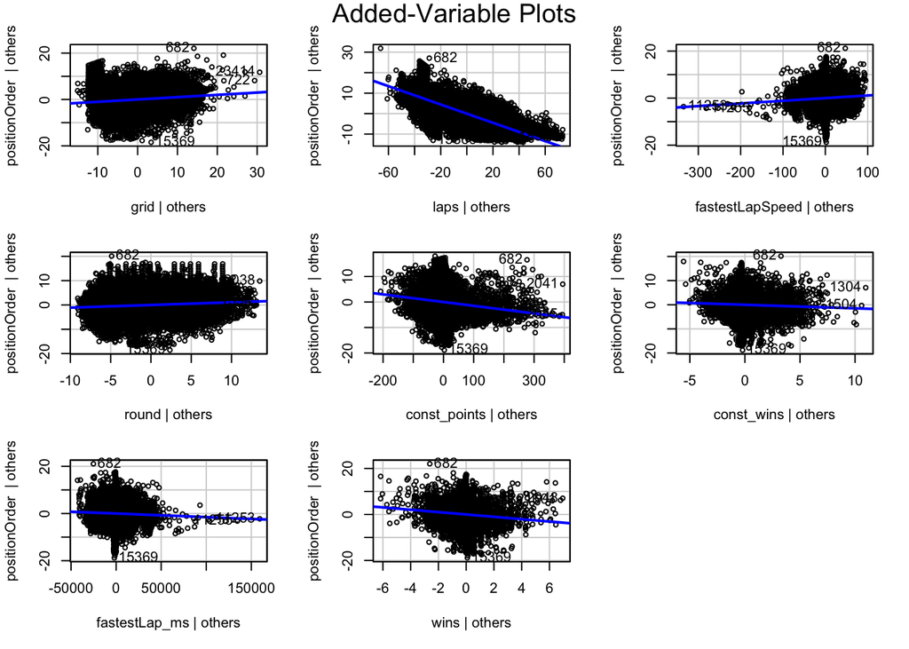

```r
avPlots(linearmodel)
```

As we can see the linear model obtain an R-squared of 65% that confirms a good capacity of the model to represent variability in the original data. Also, the majority of variables are strongly significant.

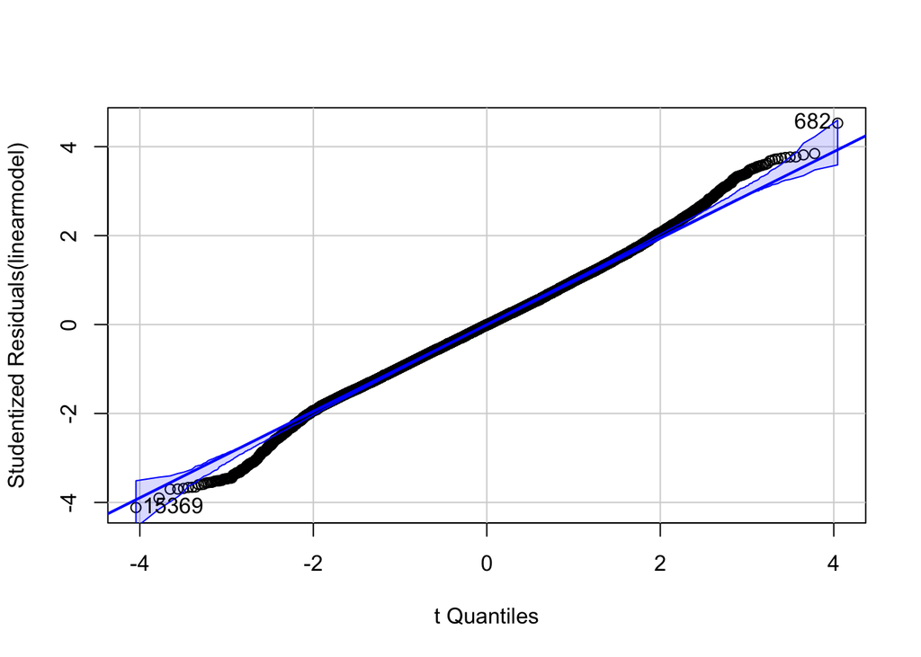

```
##   682 15369
##   522 12656
```

In order to test the significance of the whole model, we should first look at the normality of the residuals. From the qqplot presented above, it’s clear how the residuals follow aproximately a normal distribution (they lie on a straight line as normal residuals should). Looking at the F-test value of the model, it’s clear how the really low value suggests a strong significance of the whole regression. Hence we can say the model does a better job in describing the dataset than just the mean.

We can now try to run a prediction and recall `score_regression` function to see the results of the prediction.

```r
predict_lm = predict(linearmodel, df.test)
score_regression(df.test, predict_lm)
```

```
## [1] 0.6551724
```

#### Regression tree

```r
regr_tree = tree(positionOrder ~ grid + number + laps + fastestLapSpeed
                          + round + const_points + const_wins + driver_age
                          + fastestLap_ms + wins, df.train)
predict_rt = predict(regr_tree, newdata = df.test)
score_regression(df.test, predict_rt)
```

```
## [1] 0.4433498
```

### CLASSIFICATION

Using the features class `winner` that we have created, we want to predict the probability of class=1 (winner) or class=0 (not winner). Then we are going to sort the probabilities and pick the greater probability of class=1, hence the driver with the greatest probability of being a winner.

For the classification methods, we decided to remove those categorical features as `status`, `fullname` and `const_name` that when converted in factors where causing problems in the application of the techniques, or drastically reduced performances due to their dimension (all of those 3 factors presented more than 100 levels that were not accepted by the functions or ruined the prediction accuracy).

#### BAYES CLASSIFIER

```r
df.nb <- naiveBayes(winner ~ . -number -positionOrder -resultId -points -status
                    -fullname -const_name, data = df.train)
prediction_nb <- predict(df.nb, newdata = df.test, type = 'raw')
score_classification(df.test, prediction_nb)
```

```
## [1] 0.4975369
```

#### DECISION TREES

```r
df.dt = rpart(winner ~ . -number -positionOrder -resultId -points -status
              -fullname -const_name -dob -date, data = df.train, method="class")
prediction_dt = predict(df.dt, newdata = df.test, method="prob")
score_classification(df.test, prediction_dt)
```

```
## [1] 0.6059113
```

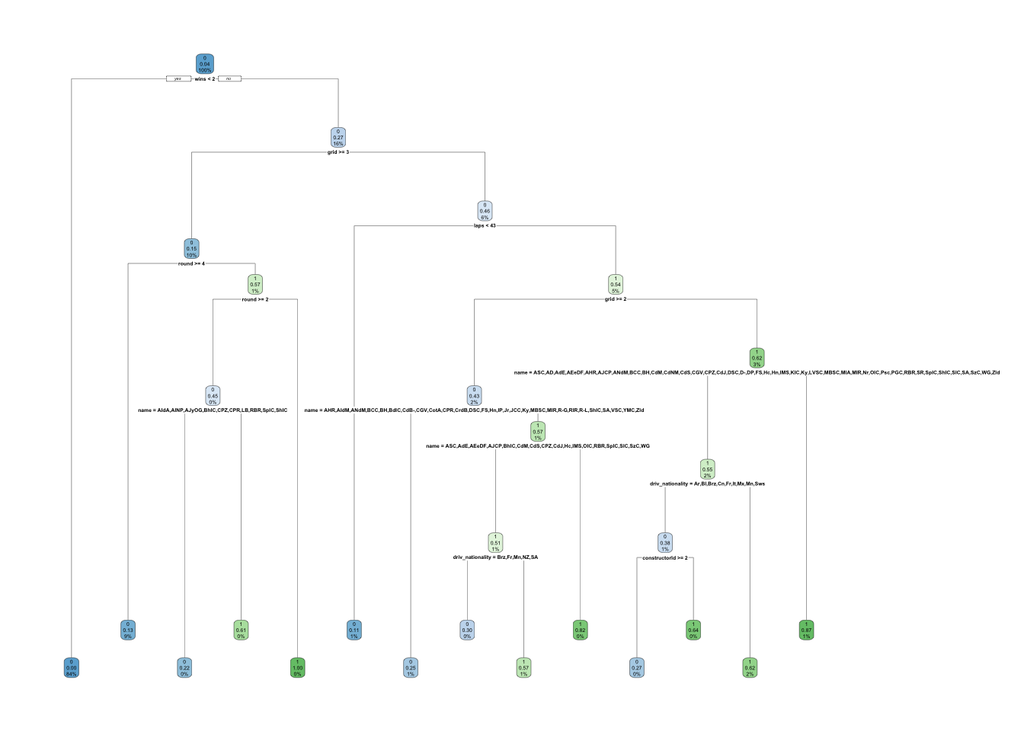

```r
rpart.plot(df.dt,faclen = 2)
```

```r
df.dt$variable.importance
```

```
##             wins       const_wins             grid             name
##      393.3741331      160.6850472      146.7874009       72.4857199
##             laps     const_points            round         driverId
##       61.9863097       56.7258929       56.2524128       33.3049220
## driv_nationality        circuitId    fastestLap_ms    constructorId
##       24.1579726       16.6447694        9.0493660        7.9804546
##  fastestLapSpeed           raceId       driver_age
##        4.3038854        2.7850395        0.7875718
```

Also, we may want to validate the tree by looking at the complexity parameters through cross validation.

```r
printcp(df.dt)
```

```
##
## Classification tree:
## rpart(formula = winner ~ . - number - positionOrder - resultId -
##     points - status - fullname - const_name - dob - date, data = df.train,
##     method = "class")
##
## Variables actually used in tree construction:
## [1] constructorId    driv_nationality grid             laps
## [5] name             round            wins
##
## Root node error: 809/19047 = 0.042474
##
## n= 19047
##
##         CP nsplit rel error  xerror     xstd
## 1 0.027606      0   1.00000 1.00000 0.034403
## 2 0.019778      5   0.80964 0.95426 0.033642
## 3 0.019159      6   0.78986 0.92336 0.033115
## 4 0.013597      8   0.75155 0.90606 0.032816
## 5 0.012979      9   0.73795 0.90235 0.032751
## 6 0.010507     11   0.71199 0.90729 0.032837
## 7 0.010000     13   0.69098 0.90358 0.032773
```

And select the number of splits with the lowest error.

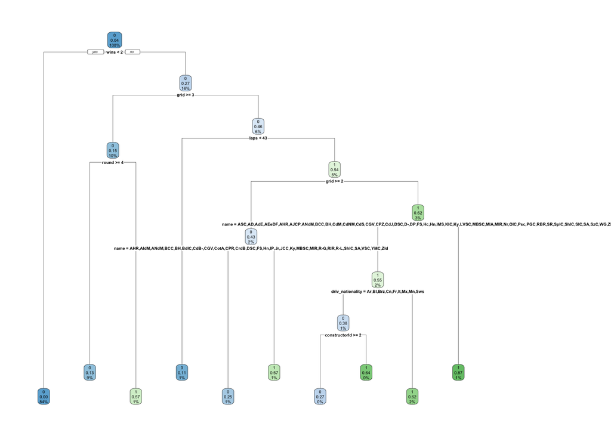

```r
pruned.df.dt = prune(df.dt, cp=df.dt$cptable[which.min(df.dt$cptable[,"xerror"]),"CP"])
rpart.plot(pruned.df.dt,faclen = 2)
```

As we can see the tree graph contain less splits and we may now try again to predict the values of `df.test` using this time the reduced tree.

```r
prediction_dt_pruned = predict(pruned.df.dt, newdata = df.test, method="prob")
score_classification(df.test, prediction_dt_pruned)
```

```
## [1] 0.6009852
```

#### RANDOM FOREST

```r
df.rf <- randomForest(winner ~ . -number -points -positionOrder -resultId
                      -const_name -name -fullname -status, data = df.train,
                      ntree = 200)
prediction.rf <- predict(df.rf, df.test, type = 'prob')
prediction.rf[is.na(prediction.rf)] <- 0
score_classification(df.test, prediction.rf)
```

```
## [1] 0.6256158
```

#### SVM classifier

```r
df.lsvm = svm(winner ~ ., data = df.train[, -c(5,6,8,9,12,13,15,17)],
              kernel = 'linear', fitted = FALSE, probability = TRUE)
prediction_svm <- predict(df.lsvm, newdata = df.test[,-c(5,6,8,9,12,13,15,17)],
                          fitted = FALSE, probability = TRUE)
SVM_class = data.frame(attributes(prediction_svm)$probabilities)
score_classification(df.test, SVM_class)
```

```
## [1] 0.5763547
```

### Visualize final prediction results

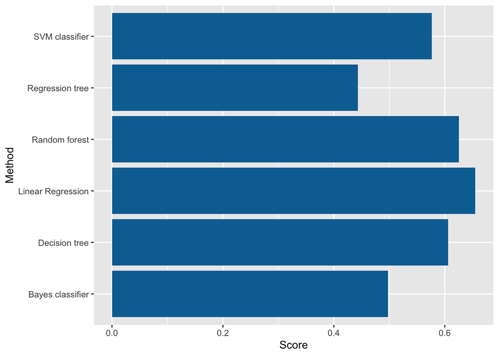

```r
accuracy_results = data.frame(c(score_regression(df.test, predict_lm),
                                score_regression(df.test, predict_rt),
                                score_classification(df.test, prediction_nb),
                                score_classification(df.test, prediction_dt),
                                score_classification(df.test, prediction.rf),
                                score_classification(df.test, SVM_class)),
                              c('Linear Regression', 'Regression tree',
                                'Bayes classifier','Decision tree','Random forest',
                                'SVM classifier'))
colnames(accuracy_results) = c('score', 'method')

ggplot(accuracy_results, aes(x = score, y = method)) +
  labs(x = 'Score', y = 'Method') +
  geom_bar(stat = "identity") +
  geom_col(fill = "#076fa2")
```

# CONCLUSIONS

Our initial goal wasn’t to analyze deeply the data that characterize a Formula 1 Race, but rather try to predict the winner of a Race with the least possible number of numerical and categorical features, while trying to maintain the integrity of the original data for the interpretation.

If we look at the last chart with all the accuracy score computed from both regression and classification models, we can see quite good results: all of the models predicted correctly the winner with at least an accuracy of about 40%. Other models reached an accuracy above 60%. The Bayes model should be seen like a benchmark for the other classifiers, but in many cases during the testing of the models has reached accuracy rate that were comparable with other techniques. Overall, the best results (considering also the computational costs) were provided by the linear regression model that never reached accuracy rates below 55% and in many cases reached a peak of 70%. This confirms again the variety of situations in which this model can be applied without much difficulties in interpretation.